# Lecture 2 -- Digital software for simulating quantum dynamics

Edwin Ng (16 July 2021)

## Introduction

What are some useful features provided by software packages for quantum simulation?

- Numerical representations of quantum states (e.g., as vectors)
- Numerical representations of quantum operators (e.g., as matrices/tensors)
- Convenience constructors for common states/operators -- Fock states, projectors, ladder operators, etc.
- Convenience functions for quantum-specific algebra -- expectations, tensor products, partial traces, etc.
- Routines for computing special states like eigenstates, dynamical steady states, etc.
- Routines for calculating dynamics (e.g., Schrodinger equation, Monte Carlo wavefunction)
- Methods for visualizing quantum states and properties (e.g., phase space distributions, histograms, correlation spectra)

### When are quantum simulations useful?

Quantum states and quantum dynamics are intrinsically multi- (and often high-) dimensional. Numerical experiments can be helpful if used right.

- Getting intuition about how small-scale quantum systems behave
- Especially useful when detailed information about *dynamics* are desired
- Designing quantum experiments and predicting/analyzing/validating experimental results/data

### Limitations

- In general, quantum systems cannot be efficiently simulated ("quantum advantage"?)
- Semiclassical systems can also be hard to simulate using software meant for quantum systems
- Workflow and abstractions are still rather low-level: quantum systems are specified from bottom up on the device level
- Systematic numerical methodology is important to ensure physical results (always run checks for convergence!)

### Software ecosystem

There are *many* software packages out there for simulating quantum physics -- https://quantiki.org/wiki/list-qc-simulators. Fair to say they are all specialized for some class of systems/states someone cares about.

For the subfield of **quantum optics**, the most generally useful packages provide capabilities for interacting **photonic modes** and/or **atoms**, with an emphasis on **open quantum system dynamics**.

We focus on the "Quantum Optics Toolbox" family:

- *qotoolbox* (MATLAB): https://qo.phy.auckland.ac.nz/toolbox/
- *QuTiP* (Python): https://qutip.org/
- *QuantumOptics.jl* (Julia): https://qojulia.org/

Code below will be for QuTiP (results are usually portable among QO toolboxes).

## Code appendix: Library imports

```python
%matplotlib inline
import matplotlib
matplotlib.rcParams["figure.dpi"] = 100
```

```python
from math import *
import numpy as np
import qutip as qt
import matplotlib.pyplot as plt
import matplotlib.cm as cm
```

```python
import matplotlib.animation as ani
from IPython.display import Video
```

## Part 1: Visualizing quantum states

Let's take a look at some quantum states. States are just vectors in Hilbert space, so the most natural representation of a quantum state is a vector of complex numbers. QuTiP provides convenience functions for constructing common states and visualization options for thinking about them.

### Spin 1/2 (qubit) states

The simplest quantum state is a *2-level system*, equivalent to a qubit or a spin-1/2 atom. It has the general form

$$ |\psi\rangle = \cos(\theta/2) |0\rangle + e^{\mathrm{i}\phi}\sin(\theta/2) |1\rangle, $$

where $|0\rangle$ and $|1\rangle$ are the "spin-up" and "spin-down" states. They are one possible basis, consisting of the eigenstates of the Pauli-Z operator $\hat\sigma_z$ with eigenvalues $+1$ and $-1$ respectively.

The coordinates $(\theta,\phi)$ nicely parameterize a spherical coordinate system with unit radius. There is however, an "odd" factor of two in the polar angle, making "up" and "down" orthogonal.

```python
ψ0 = qt.basis(2,0)
ψ0
```

Quantum object: dims = [[2], [1]], shape = (2, 1), type = ket\begin{equation*}\left(\begin{array}{*{11}c}1.0\\0.0\\\end{array}\right)\end{equation*}

```python
ψ1 = qt.basis(2,1)
ψ1
```

Quantum object: dims = [[2], [1]], shape = (2, 1), type = ket\begin{equation*}\left(\begin{array}{*{11}c}0.0\\1.0\\\end{array}\right)\end{equation*}

```python
θ = pi/4
ϕ = -pi/3
ψ = cos(θ/2)*ψ0 + np.exp(1j*ϕ)*sin(θ/2)*ψ1
ψ
```

Quantum object: dims = [[2], [1]], shape = (2, 1), type = ket\begin{equation*}\left(\begin{array}{*{11}c}0.924\\(0.191-0.331j)\\\end{array}\right)\end{equation*}

```python
_, (ψx1,ψx0) = qt.sigmax().eigenstates()
ψx0
```

Quantum object: dims = [[2], [1]], shape = (2, 1), type = ket\begin{equation*}\left(\begin{array}{*{11}c}0.707\\0.707\\\end{array}\right)\end{equation*}

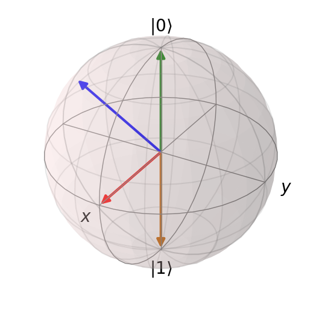

```python
bsphere = qt.Bloch()
bsphere.add_states([ψ0,ψ1,ψ,ψx0])
bsphere.show()
```

### States of the harmonic oscillator

Another quantized degree of freedom central to quantum optics is the quantum harmonic oscillator, or more specifically a quantized *harmonic oscillator mode*. States of the harmonic oscillator mode have the general form

$$ |\phi\rangle = \sum_{n=0}^{\infty} c_n |n\rangle, $$

where $|n\rangle$ is an eigenstate of the number operator $\hat n = \hat a^\dagger \hat a$, for mode *annihilation and creation operators* satisfying $[\hat a, \hat a^\dagger] = 1$.

For numerical simulations, the infinite sum cannot be represented, so we instead choose a cutoff $N_\text{fock}$. This requires that we deal with states that have bounded excitation ($c_n \approx 0$ for $n > N_\text{fock}$). This also means that, numerically, there isn't that much difference between a $d$-level atom and a harmonic oscillator mode truncated to $N_\text{fock} = d$.

For a mode to exist, there must be some physical Hamiltonian $\hbar\omega(\hat a^\dagger \hat a + 1/2)$ that defines it and its natural oscillation frequency. However, we often work in a rotating frame in which this term (which produces trivial dynamics) can be ignored. Instead, our "Hamiltonians" will be numerically specified as *perturbations* of the physical Hamiltonian. Some examples are:

- Detuning: $\Delta\hat a^\dagger \hat a$ ($\Delta \ll \omega$)
- Linear mode coupling: $\theta(\hat a^\dagger \hat b + \hat a \hat b^\dagger)$
- Coherent driving: $\alpha \hat a^\dagger + \alpha^* \hat a$
- Squeezing: $\eta(a^2 + a^{\dagger2})$
- Kerr nonlinearity: $\chi \hat a^{\dagger2} \hat a^2$
- Many more...

Numerically, we represent the state in the *Fock basis*, but another representation is given by the *canonical position and momentum operators*

$$ \hat q = \frac{\hat a + \hat a^\dagger}{\sqrt{2}} \qquad\quad \hat p = \frac{\hat a - \hat a^\dagger}{\sqrt{2}\mathrm{i}}. $$

If $\phi(q) = \sum_n c_n \langle q | n \rangle$, then $$ |\phi\rangle = \int_{-\infty}^{\infty} \mathrm{d}q \, \phi(q) \, |q\rangle. $$

Here, $|q\rangle$ are the eigenstates of $\hat q$ (delta functions), $\phi(q)$ is the (position-basis) *wavefunction* of the state, and $\langle q|n \rangle$ are the (position-basis) wavefunctions of the eigenstates of the quantum harmonic oscillators (Hermite-Gauss functions). If you've studied the second quantization of the (single-particle, nonrelativistic) harmonic oscillator, this is just going backwards through the derivation.

Intuitively:

- A mode oscillates with some amplitude, and states of quantized amplitude correspond to the Fock basis
- The cosine and sine components of the oscillation correspond to the canonical position and momentum
- For modes where "position" and "momentum" do not have the usual particle meaning (e.g., electromagnetic modes), they're often called the *position and momentum quadratures* or sometimes *in-phase and quadrature components*

Because quadratures are so useful for understanding the state of an oscillator mode, we often represent the state in terms of its quadratures. There are many such *phase-space representations* (e.g., Glauber-Sudarshan P, Husimi Q, Wigner, etc.), but we will go with the Wigner representation in our visualizations.

The formal description of the Wigner function is a bit complicated (see References for excellent introductions). However, very roughly:

- For each quantum state $|\phi\rangle$ of a single mode there is a corresponding Wigner function $W_\phi(q,p): \mathbb R^2 \mapsto \mathbb R$.
- It is a quasi-probability distribution: $\int W_\phi(q,p) \, \mathrm{d}p = |\langle q | \phi \rangle|^2$ (and vice-versa for $q$), but $W(q,p)$ can be negative (a sign of non-classicality)!
- Thus it gives a sense for how measurements of $\hat q$ and $\hat p$ might be distributed, and how they might also be correlated.

```python
Nfock = 20
```

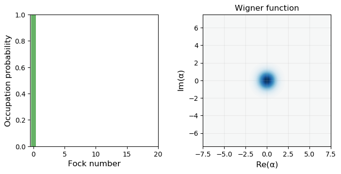

```python
ϕ0 = qt.basis(Nfock,0)

qt.plot_wigner_fock_distribution(ϕ0, figsize=(8,3.6))
plt.subplots_adjust(wspace=0.35)
plt.grid(alpha=0.2)
```

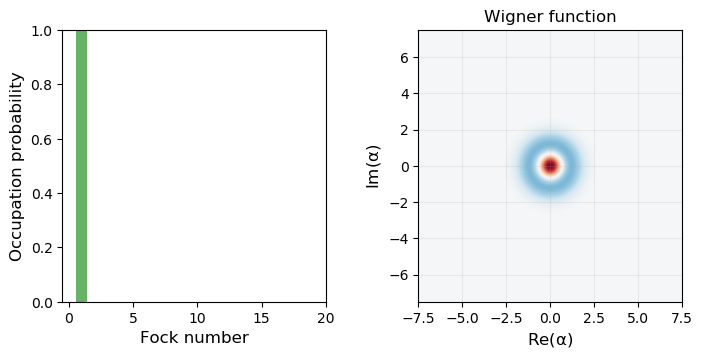

```python
ϕ1 = qt.basis(Nfock,1)

qt.plot_wigner_fock_distribution(ϕ1, figsize=(8,3.6))
plt.subplots_adjust(wspace=0.35)
plt.grid(alpha=0.2)
```

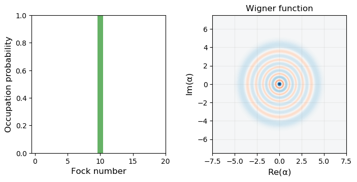

```python
ϕ10 = qt.basis(Nfock,10)

qt.plot_wigner_fock_distribution(ϕ10, figsize=(8,3.6))
plt.subplots_adjust(wspace=0.35)
plt.grid(alpha=0.2)
```

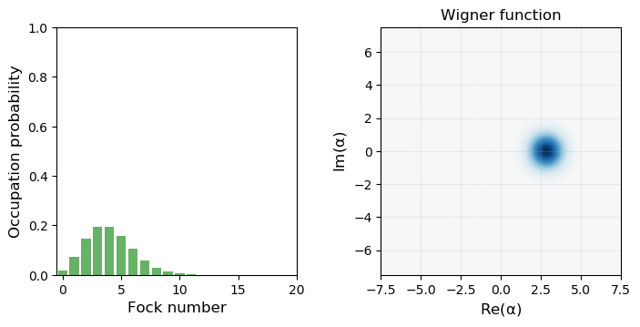

```python
α = 2
ϕ_disp = qt.coherent(Nfock,α)

qt.plot_wigner_fock_distribution(ϕ_disp, figsize=(8,3.6))
plt.subplots_adjust(wspace=0.35)
plt.grid(alpha=0.2)
```

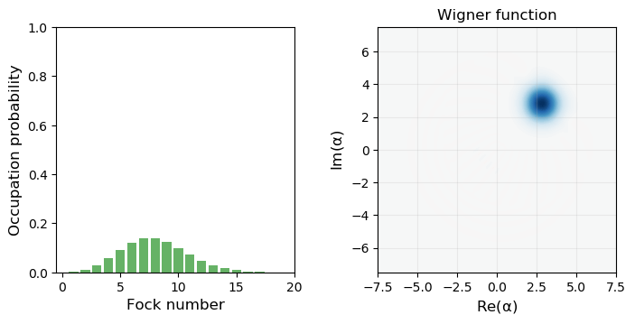

```python
α = 2+2j
ϕ_disp = qt.displace(Nfock,α) * ϕ0

qt.plot_wigner_fock_distribution(ϕ_disp, figsize=(8,3.6))
plt.subplots_adjust(wspace=0.35)
plt.grid(alpha=0.2)
```

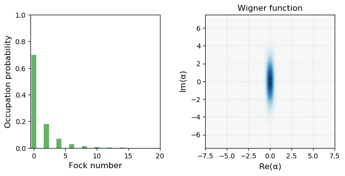

```python
η = 0.9
ϕ_sqz = qt.squeeze(Nfock,η) * ϕ0

qt.plot_wigner_fock_distribution(ϕ_sqz, figsize=(8,3.6))
plt.subplots_adjust(wspace=0.35)
plt.grid(alpha=0.2)
```

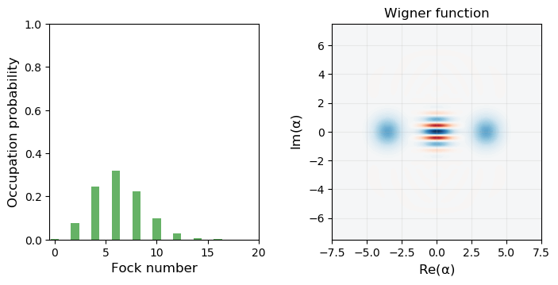

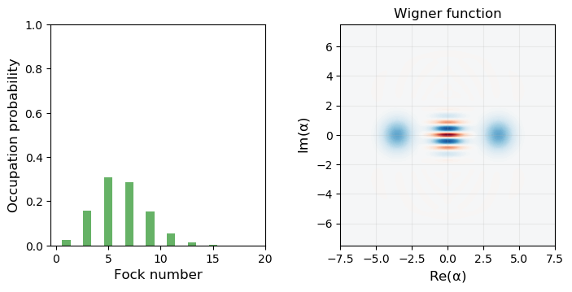

```python
α = 2.5
ϕ_cat1 = (qt.coherent(Nfock,α) + qt.coherent(Nfock,-α)).unit()
ϕ_cat2 = (qt.coherent(Nfock,α) - qt.coherent(Nfock,-α)).unit()

qt.plot_wigner_fock_distribution(ϕ_cat1, figsize=(8,3.6))
plt.subplots_adjust(wspace=0.35)
plt.grid(alpha=0.2)

qt.plot_wigner_fock_distribution(ϕ_cat2, figsize=(8,3.6))
plt.subplots_adjust(wspace=0.35)
plt.grid(alpha=0.2)
```

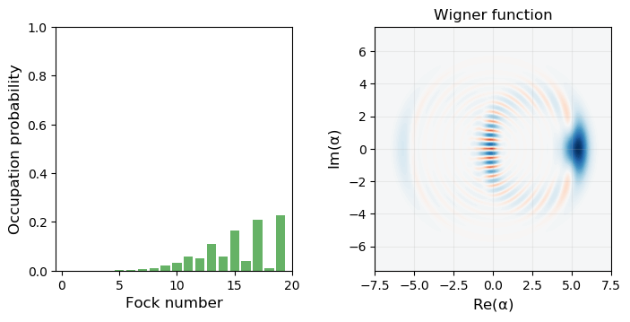

```python
α = 4.0
ϕ_disp = qt.coherent(Nfock,α) # Truncated!

qt.plot_wigner_fock_distribution(ϕ_disp, figsize=(8,3.6))
plt.subplots_adjust(wspace=0.35)
plt.grid(alpha=0.2)
```

### Entanglement and partial trace

Most interesting quantum systems are also composed of multiple subsystems, so we also need ways to construct composite quantum systems via the tensor product.

```python
ψ = qt.tensor(ψ0,ψx0)
ψ
```

Quantum object: dims = [[2, 2], [1, 1]], shape = (4, 1), type = ket\begin{equation*}\left(\begin{array}{*{11}c}0.707\\0.707\\0.0\\0.0\\\end{array}\right)\end{equation*}

```python
ψ = (qt.tensor(ψ1,ψx0) + qt.tensor(ψ0,ψ1)).unit()
ψ
```

Quantum object: dims = [[2, 2], [1, 1]], shape = (4, 1), type = ket\begin{equation*}\left(\begin{array}{*{11}c}0.0\\0.707\\0.500\\0.500\\\end{array}\right)\end{equation*}

```python
ρ0 = ψ.ptrace(0)
ρ1 = ψ.ptrace(1)
ρ0
```

Quantum object: dims = [[2], [2]], shape = (2, 2), type = oper, isherm = True\begin{equation*}\left(\begin{array}{*{11}c}0.500 & 0.354\\0.354 & 0.500\\\end{array}\right)\end{equation*}

```python
ρ1
```

Quantum object: dims = [[2], [2]], shape = (2, 2), type = oper, isherm = True\begin{equation*}\left(\begin{array}{*{11}c}0.250 & 0.250\\0.250 & 0.750\\\end{array}\right)\end{equation*}

```python
ρ0.purity(), ρ1.purity()
```

```
(0.7499999999999999, 0.7499999999999999)
```

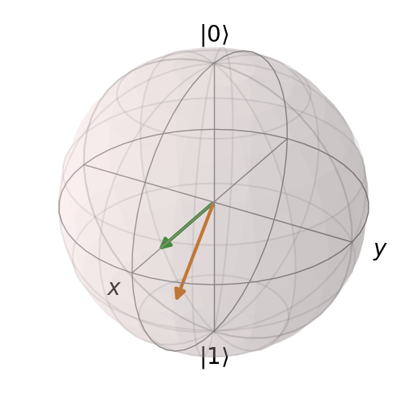

```python
bsphere = qt.Bloch()
bsphere.add_states([ρ0,ρ1])
bsphere.show()
```

```
(0, 0.05)
```

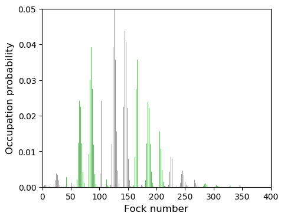

```python
ϕ = (qt.tensor(ϕ_cat1,ϕ_cat1) + qt.tensor(ϕ_cat2,ϕ_cat2)).unit()
qt.plot_fock_distribution(ϕ, figsize=(5,4))
plt.ylim(0,0.05);
```

```
0.49999999999999983
```

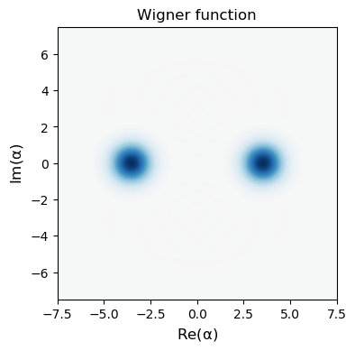

```python
ρ = ϕ.ptrace(0)
qt.plot_wigner(ρ, figsize=(4,4))
ρ.purity()
```

## Part 2: Closed and open quantum dynamics

For *closed systems*, time evolution is governed by the Schrodinger equation. We simply need to specify a Hamiltonian $\hat H$ made up of system operators and the state is given by $\mathrm{i}\partial_t |\psi\rangle = \hat H |\psi\rangle$, or if we let $\hat\rho$ be a density matrix, then more generally, $\mathrm{i}\partial_t \hat\rho = \big[\hat H, \hat\rho\big]$.

For *open systems*, the entire environment in principle needs to take part in the dynamics, which would be intractable due to the essentially infinite number of degrees of freedom it introduces.

*Quantum input-output theory* is a way of treating the reservoir without incurring this cost. It works when the system only weakly excites the reservoir, because the coupling is weak and the reservoir is large.

[figure not shown]

*Image credit*: R. Hamerly, PhD Thesis, Stanford University, 2018, Fig. 1.1

Very roughly, the physical arguments go as follows:

1. Start with a full Schrodinger equation for the evolution of the system and reservoir
2. Attempt to partial-trace out the reservoir
3. Make a *Born approximation*: When calculating the perturbative contribution of the total system+reservoir state to the reduced system state's differential evolution, assume that the system and reservoir can be factorized, and the reservoir part of the state is time-independent.
4. Make a *Markov approximation*: Even after everything above, the resulting equation of motion still has memory: it depends on an integral of the system's state history. If the reservoir is very large, we can assume its memory kernel is sharply peaked (e.g., a delta function in correlation time), which turns the integral into a constant coupling rate.

The resulting *master equation in Lindblad form* is

$$ \partial_t \hat\rho = -\mathrm{i}\left[\hat H, \hat\rho\right] + \sum_i \left(\hat L_i\hat\rho\hat L_i^\dagger - \frac 1 2 \left\{\hat L_i^\dagger\hat L_i, \hat\rho\right\}\right). $$

- The operators $\hat L_i$ are *Lindblad operators* that characterize the effect of each reservoir the system is coupled with. Can be viewed as "dissipation channels" through which state information can leak out.
- This is a linear equation of motion (just like the Schrodinger equation) in $\hat\rho$. The linear superoperator acting on $\hat\rho$ is the *Liouvillian* or sometimes the *Lindbladian*.

### Closed system dynamics

We start with the foundational model of light-matter interaction in quantum optics: the *Jaynes-Cummings model*. This system involves one qubit and one oscillator mode which exchange excitations with a coupling rate $g$:

$$ \hat H_\text{JC} = g\left(\hat\sigma^\dagger\hat a + \hat\sigma\hat a^\dagger\right). $$

This model can be very rich, but we focus on just the basics here, so we ignore detuning and drive.

```python
Nfock_jc = 5
σ = qt.tensor(qt.sigmam(),qt.qeye(Nfock_jc))
a_jc = qt.tensor(qt.qeye(2),qt.destroy(Nfock_jc))
```

```python
g = 1
H_jc = g*(σ.dag()*a_jc + σ*a_jc.dag())
```

```python
ψ0_jc = qt.tensor(qt.basis(2,0), qt.coherent(Nfock_jc,0))
t_jc = np.linspace(0, 10, 150)
jc_sol = qt.sesolve(H_jc, ψ0_jc, t_jc, e_ops=[σ.dag()*σ, a_jc.dag()*a_jc])
```

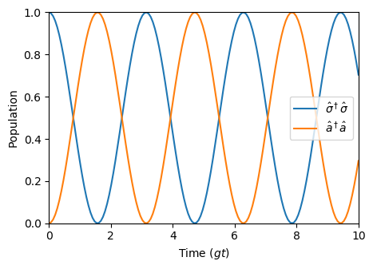

```python
fig = plt.figure(figsize=(5,3.5))

plt.plot(t_jc, jc_sol.expect[0], label=r"$\hat\sigma^\dagger\hat\sigma$")
plt.plot(t_jc, jc_sol.expect[1], label=r"$\hat a^\dagger\hat a$")

plt.xlabel(r"Time ($gt$)")
plt.ylabel("Population")
plt.xlim(0,t_jc[-1])
plt.ylim(0,1)
plt.legend();
```

Another interesting example that does not involve atomic degrees of freedom is the Kerr resonator:

$$ \hat H_\text{Kerr} = \chi \hat a^{\dagger2} \hat a^2 $$

```python
Nfock_kerr = 20
a_kerr = qt.destroy(Nfock_kerr)
```

```python
χ = 1
H_kerr = χ * a_kerr.dag()**2 * a_kerr**2
```

```python
ψ0_kerr = qt.coherent(Nfock_kerr, 2.0)
t_kerr = np.linspace(0, 5, 150)
kerr_sol = qt.sesolve(H_kerr, ψ0_kerr, t_kerr)
```

```python
x = np.linspace(-5, 5, 150)
wigner_traj = [qt.wigner(ψ,x,x) for ψ in kerr_sol.states]
```

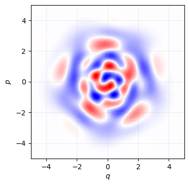

```python
fig = plt.figure(figsize=(4,4))
img = plt.imshow(wigner_traj[-1], extent=[x[0],x[-1],x[0],x[-1]],
                 vmin=-0.36, vmax=0.36, cmap='seismic_r')
plt.xlabel(r"$q$")
plt.ylabel(r"$p$")
plt.grid(alpha=0.2);
```

```python
def animate(j):
    img.set_array(wigner_traj[j])
    return img,

anim = ani.FuncAnimation(fig, animate, frames=len(t_kerr), interval=100, blit=True, repeat_delay=2000)
anim.save('kerr_closed.mp4', writer='ffmpeg')
```

```python
Video("movies/kerr_closed.mp4")
```

[video not shown]

### Open system dynamics

It is straightforward to introduce dissipation in QuTiP. For both systems, we can model photon loss in the cavity using a Lindblad operator $\hat L = \sqrt{2\kappa} \hat a$.

```python
κ = 0.25
L_jc = sqrt(2*κ)*a_jc
```

```python
jc_sol = qt.mesolve(H_jc, ψ0_jc, t_jc, c_ops=[L_jc], e_ops=[σ.dag()*σ, a_jc.dag()*a_jc])
```

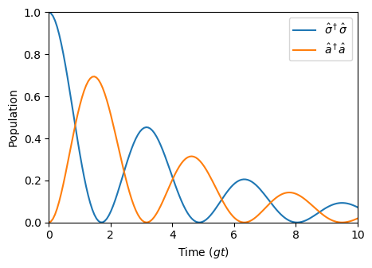

```python
fig = plt.figure(figsize=(5,3.5))

plt.plot(t_jc, jc_sol.expect[0], label=r"$\hat\sigma^\dagger\hat\sigma$")
plt.plot(t_jc, jc_sol.expect[1], label=r"$\hat a^\dagger\hat a$")

plt.xlabel(r"Time ($gt$)")
plt.ylabel("Population")
plt.xlim(0,t_jc[-1])
plt.ylim(0,1)
plt.legend();
```

We can also run the same master equation simulation for the Kerr system.

```python
L_kerr = sqrt(2*κ)*a_kerr
```

```python
kerr_sol = qt.mesolve(H_kerr, ψ0_kerr, t_kerr, c_ops=L_kerr)
```

```python
wigner_traj = [qt.wigner(ψ,x,x) for ψ in kerr_sol.states]
```

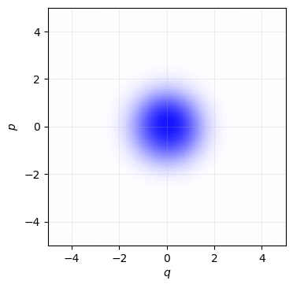

```python
fig = plt.figure(figsize=(4,4))
img = plt.imshow(wigner_traj[-1], extent=[x[0],x[-1],x[0],x[-1]],
                 vmin=-0.36, vmax=0.36, cmap='seismic_r')
plt.xlabel(r"$q$")
plt.ylabel(r"$p$")
plt.grid(alpha=0.2)
```

```python
def animate(j):
    img.set_array(wigner_traj[j])
    return img,

anim = ani.FuncAnimation(fig, animate, frames=len(t_kerr), interval=100, blit=True, repeat_delay=2000)
anim.save('kerr_open.mp4', writer='ffmpeg')
```

```python
Video("movies/kerr_open.mp4")
```

[video not shown]

## Part 3: Quantum measurement

Information leaked out of the system into the reservoir is not necessarily lost completely!

- We can't track the reservoir's full quantum state but can convert its entanglement with the system into classical information via *measurement*.
- Quantum measurements have intrinsic uncertainty, so the results are *stochastic* -- we obtain a "measurement record".
- After the measurement, the system state partially collapses into the part of the wavefunction consistent with the measurement result -- the system undergoes a "quantum jump" or experiences "backaction" due to the measurement.
- The conditional dynamics of the system thus *depend* on the measurement model used.
- Averaging any physical quantity over multiple measurement records (i.e., throwing away measurement information) results in the same result as calculating that quantity using the Lindblad master equation.
- The conditional dynamics are an "unravelling" of the master equation.

[figure not shown]

*Image credit*: (Left) Y. Yamamoto, PHI Lab Lecture #1 (2021) , Fig. 2.5; (Right) R. Hamerly, PhD Thesis, Stanford University (2018), Fig. 1.2

Within input-output theory:

- The interactions with the reservoir take place continuously in every differential time step
- Each interaction is infinitesimally weak, but there are infinitely many interactions
- The reservoir before the interaction is uncorrelated with the system and in a known (e.g., vacuum) state
- After the interaction, the reservoir is weakly entangled with the system, but we immediately measure its state according to a specified measurement model

Some useful measurement models include:

- *Photon counting*: Basis for the Monte Carlo wavefunction (MCWF) method. In each time step, we either get no click (evolve deterministically according to a non-Hermitian Hamiltonian) or we get a single click (perform a quantum jump to remove a photon from the system (for the case where the Lindblad operator is $\propto \hat a$).
- *Homodyne*: Same idea as photon counting, but now bias the output with a strong classical *local oscillator*. Then, there will be a jump of some kind every time step, but they are "infinitely small jumps (which) occur infinitely frequently" [6]. Notably gives continuous monitoring of a quadrature, chosen by the local oscillator.
- *Heterodyne*: Similar to homodyne, but for both quadratures at once (producing a complex number as measurement result).

[figure not shown]

*Image credit*: R. Hamerly, PhD Thesis, Stanford University (2018), Fig. 1.4

### Decay of vacuum Rabi oscillations

One simple example is to perform photon counting on the vacuum Rabi oscillations to see how the stochastic trajectories relate to the master equation simulation.

```python
jc_mc = qt.mcsolve(H_jc, ψ0_jc, t_jc, c_ops=[L_jc], ntraj=100)
```

```
10.0%. Run time:   0.05s. Est. time left: 00:00:00:00
20.0%. Run time:   0.07s. Est. time left: 00:00:00:00
30.0%. Run time:   0.08s. Est. time left: 00:00:00:00
40.0%. Run time:   0.09s. Est. time left: 00:00:00:00
50.0%. Run time:   0.11s. Est. time left: 00:00:00:00
60.0%. Run time:   0.12s. Est. time left: 00:00:00:00
70.0%. Run time:   0.14s. Est. time left: 00:00:00:00
80.0%. Run time:   0.15s. Est. time left: 00:00:00:00
90.0%. Run time:   0.16s. Est. time left: 00:00:00:00
100.0%. Run time:   0.18s. Est. time left: 00:00:00:00
Total run time:   0.24s
```

```python
expt_n = [qt.expect(a_jc.dag()*a_jc, traj) for traj in jc_mc.states]
expt_z = [qt.expect(σ.dag()*σ, traj) for traj in jc_mc.states]
```

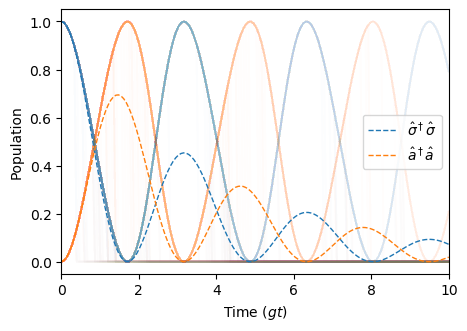

```python
fig = plt.figure(figsize=(5,3.5))
cmap = cm.get_cmap('tab10')

for n_traj,z_traj in zip(expt_n,expt_z):
    plt.plot(t_jc, z_traj, color=cmap(0), alpha=0.01)
    plt.plot(t_jc, n_traj, color=cmap(1), alpha=0.01)
plt.plot(t_jc, jc_sol.expect[0], "--", linewidth=1, color=cmap(0),
         label=r"$\hat\sigma^\dagger\hat\sigma$")
plt.plot(t_jc, jc_sol.expect[1], "--", linewidth=1, color=cmap(1),
         label=r"$\hat a^\dagger\hat a$")

plt.xlabel(r"Time ($gt$)")
plt.ylabel("Population")
plt.xlim(0,t_jc[-1])
plt.ylim(0-0.05,1.05)
plt.legend();
```

### Degenerate OPO near threshold

Our last model will be a single-mode system for which dissipation plays a big role in much of its qualitative behavior: the *degenerate optical parametric oscillator* (DOPO). The model consists of a squeezing Hamiltonian

$$ \hat H_\text{dopo} = \frac{\mathrm{i}r}{2} \left(a^{\dagger2} - a^2\right) $$

and two Lindblad operators $\hat L_\text{lin} = \sqrt{2\kappa} \hat a$ and $\hat L_\text{nl} = \sqrt{\eta} \hat a^2$. The latter Lindblad operator is actually *nonlinear* and is responsible for thresholding behavior in the DOPO, since for $r > \kappa$, the linear part of the dynamics is actually *unstable*; the nonlinearity is thus a dissipative term that stablizes the system.

```python
Nfock = 50
r = 0.95
η = 0.05
κ = 1

a = qt.destroy(Nfock)
H = 1j*r/2 * (a.dag()**2 - a**2)
L_lin = sqrt(2*κ)*a
L_nl = sqrt(η)*a**2

q = (a+a.dag())/sqrt(2)
p = (a-a.dag())/(1j*sqrt(2))
n = a.dag()*a

ψ0 = qt.basis(Nfock, 0)
t = np.linspace(0, 20, 501)
```

```python
sol_me = qt.mesolve(H, ψ0, t, [L_lin,L_nl])
sol_trajs = [
    qt.mcsolve(H, ψ0, t, [L_lin,L_nl], ntraj=1),
    qt.ssesolve(H, ψ0, t, [L_lin,L_nl], nsubsteps=100, ntraj=1),
    qt.ssesolve(H, ψ0, t, [1j*L_lin,L_nl], nsubsteps=100, ntraj=1)
]
```

```
Total run time:   0.04s
Total run time:   1.79s
Total run time:   1.77s
```

```python
x = np.linspace(-5, 5, 100)
wigner_me = qt.parallel_map(qt.wigner, sol_me.states, task_args=(x,x), num_cpus=4)
wigner_trajs = [qt.parallel_map(qt.wigner, sol.states[0], task_args=(x,x), num_cpus=4)
    for sol in sol_trajs]
```

```python
expt_me = [qt.expect(z,sol_me.states) for z in (q,p,n)]
expt_trajs = [qt.expect(z,sol.states[0]) for sol,z in zip(sol_trajs,(n,q,p))]
```

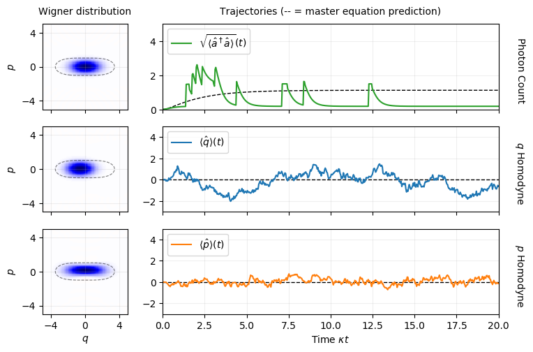

```python
fig, axs = plt.subplots(3, 2, figsize=(9,5.5), gridspec_kw={'width_ratios':[1,2.3]})
fig.subplots_adjust(wspace=0.02)

for i in range(3):
    axs[i,0].contour(x, x, wigner_me[-1], levels=[exp(-2)/(2*pi)],
        alpha=0.5, linewidths=0.8, colors='k', linestyles='--')
W_plots = [axs[i,0].imshow(W[-1], extent=[x[0],x[-1],x[0],x[-1]],
        cmap='seismic_r', vmin=-0.35, vmax=0.35, animated=True)
    for (i,W) in enumerate(wigner_trajs)]

cmap = cm.get_cmap('tab10')
axs[0,1].plot(t, expt_me[2], 'k--', linewidth=1)
axs[1,1].plot(t, expt_me[0], 'k--', linewidth=1)
axs[2,1].plot(t, expt_me[1], 'k--', linewidth=1)
n_plot, = axs[0,1].plot(t, expt_trajs[0], color=cmap(2), animated=True,
    label=r"$\sqrt{\langle \hat a^\dagger\hat a\rangle}(t)$")
q_plot, = axs[1,1].plot(t, expt_trajs[1], color=cmap(0), animated=True,
    label=r"$\langle\hat q\rangle(t)$")
p_plot, = axs[2,1].plot(t, expt_trajs[2], color=cmap(1), animated=True,
    label=r"$\langle\hat p\rangle(t)$")

axs[0,0].set_title("Wigner distribution", fontsize=10, pad=10)
axs[0,1].set_title("Trajectories (-- = master equation prediction)", fontsize=10, pad=10)
axs[2,0].set_xlabel(r"$q$")
axs[2,1].set_xlabel(r"Time $\kappa t$")
axs[0,1].text(21, 0.5, "Photon Count", rotation=-90)
axs[1,1].text(20.9, -2, r"$q$ Homodyne", rotation=-90)
axs[2,1].text(20.9, -2, r"$p$ Homodyne", rotation=-90)
axs[0,1].legend(loc='upper left')
axs[1,1].legend(loc='upper left')
axs[2,1].legend(loc='upper left')
for i in range(3):
    axs[i,0].set_ylabel(r"$p$")
    axs[i,1].set_ylim(-3*(i>0),5)
    axs[i,1].set_xlim(0,t[-1])
    axs[i,0].set_xticks([-4,0,4])
    axs[i,0].set_yticks([-4,0,4])
    for j in range(2):
        axs[i,j].grid(alpha=0.2)
        if i < 2: axs[i,j].tick_params(labelbottom=False)

fig.savefig("dopo_squeeze.png", dpi=300, bbox_inches='tight');
```

```python
def animate(j):
    for i in range(3):
        W_plots[i].set_array(wigner_trajs[i][j])
        q_plot.set_data(t[:j], expt_trajs[1][:j])
        p_plot.set_data(t[:j], expt_trajs[2][:j])
        n_plot.set_data(t[:j], expt_trajs[0][:j])
    return (*W_plots, q_plot, p_plot, n_plot)

anim = ani.FuncAnimation(fig, animate, frames=len(t), interval=20, blit=True, repeat_delay=2000)

anim.save('dopo_trajs.mp4', writer='ffmpeg');
```

```python
Video("movies/dopo_trajs.mp4")
```

[video not shown]

## References

1. QuTiP Documentation: https://qutip.org/documentation.html
2. QuTiP Tutorials: https://qutip.org/tutorials.html
3. J. R. Johansson, P.D. Nation, and F. Nori, “QuTiP 2: A Python framework for the dynamics of open quantum systems”, *Comp. Phys. Comm.* **184**, 1234-1240 (2013) [arXiv:1211.6518](https://arxiv.org/abs/1211.6518)
4. W. B. Case, "Wigner functions and Weyl transforms for pedestrians", *Am. J. Phys.* **76**, 937 (2008)
5. K. Jacobs and D. A. Steck, "A Straightforward Introduction to Continuous Quantum Measurement", *Contemp. Phys.* **47:5**, 279-303 (2007) [arXiv:0611067](https://arxiv.org/abs/quant-ph/0611067)
6. H. M. Wiseman and G. J. Milburn, *Quantum Measurement and Control* (Cambridge University Press, Cambridge, 2010)
7. R. Hamerly, "Coherent LQG Control, Free-Carrier Oscillations, Optical Ising Machines and Pulsed OPO Dynamics", PhD Thesis, Stanford University (2018). [arXiv:1608.07551](https://arxiv.org/abs/1608.07551)